# **Updated Results for paired amplicons: Danae B Dataset**

Remaking manuscript figures based on newly cleaned OTU tables

Kelli Feeser

2025-02-21

Document last updated: 2025-02-21

# Update Notes

## Feb 2025 Update Notes

### Questions and Responses:

> 1. **DB:** “First, to answer your question regarding”you would want me to remove samples without a corresponding cross-kingdom match, so if sample X128 has no 16S reads, then I should also remove it from the ITS dataset as well, and vice versa” —> No, how you did it is perfect and we would like to keep it this way (so keeping the unpaired cross-kingdom mate)“.
> - **KF:** Great! I will continue with keeping the unpaired cross-kingdom mate.

> 2. **DB:** “Figure 1: For the alpha-diversity measure, do you think you could do the same measures also within each power plant? That would allow us to see if there are changes in alpha diversity between the different sampling point in each power plant”
> - **KF:** yes [in-progress]

> 3. **DB:** “Figure 2: For the NMDS: is it possible to test the impact of environmental factors (such as temperature or pH of the fluids. The environmental factors are included in the metadata, I can send them again if needed) on the distributions? And on the general NMDS, do you think that it would be possible to change the icons of each power plant, so that we can see if the points represent the production, the heat central or the injection well? If this is not possible for all power plants, we would at least be interested to see it for Bad Blumau.”
> - **KF:** yes and yes. I do have the metadata already. [in-progress]

> 4. **DB:** “(Figure 2): Also, do you think that it would make sense to do an NMDS for each power plant separately (again, to see changes between the wells)? So that we could build a figure as the one attached (example for Heemskerk). ”
> - **KF:** I’ll try it and see! [in-progress]

> 5. **DB:** “Genus-level figures: These figures are really nice. However, for Krafla and Theistareykir, there are several production and several injection wells. Would it be possible for you to do the same figures, but spliting them by”Well” (ex. K-06) rather than by the “type of well” (production or injection)? I am sorry, I should have seen that before. And for Bad Blumau, would it be possible for you to change the order of the wells displayed (to have production - heat central - injection)? That would follow the path of the power plant itself.”
> - **KF:** Not a problem and yes! [in-progress]

> 6. **DB:** “Final figures: when we have all the final figures, would it be possible for you to send them to me as PDF, so that if we need to change small things (like sample names or things like that), I could change them myself without bothering you with details? ”
> - **KF:** Yes! My first few attempts to email over the last round of updates failed because I had included the folder of all figures generated. For that reason, I proposed hosting the updates and files on my GitHub. The webpage containing links to the analyses can be found here: https://kellifeeser.github.io/black-sheep-club/index_Danae.html. That page has links to the [Current Analyses](https://kellifeeser.github.io/black-sheep-club/github_UpdatedResults_DanaeB_kfFeb_v4.html), [Read Processing Results](https://kellifeeser.github.io/black-sheep-club/1_ReadProcessing_Danae_B_kf.html) and the [Prior Analyses (from Dec 2024/Jan 2025)](https://kellifeeser.github.io/black-sheep-club/2_UpdatedResults_DanaeB_kfDec_v3.html). The data, files, and figures produced can be downloaded from here: https://github.com/kellifeeser/black-sheep-club/tree/main/docs/DanaeB_dataset/processed_data_DB. Please let me know if you need help finding anything. The advantage of this approach is that it can let you see updates and progress in real-time. I am happy to keep communicating via email for questions, requests, editing, etc. I think this will make file sharing easier.
> - For the final figures, it is very easy for me to export and share all figures in almost any format (pdf, tiff, png, etc.). Similarly, I can export the figures to match any figure requirements of your intended journal, e.g., dimensions, resolution, font size, font family… Please feel free to just let me know what you’d like, or where you want to take over with manual edits on any figures.

> 7. **DB:** “Methods: do you think you could help me write the methods that you used? I include here attached the method section of the paper (I am re-writting the rest of the paper for the moment).”
> - **KF:** Yes again! :) You can find much of the needed information on the [Read Processing Results](https://kellifeeser.github.io/black-sheep-club/1_ReadProcessing_Danae_B_kf.html) page and throughout the analyses. Especially once you decide on the final figures and analyses you’d like to include in your manuscript, I can certainly help write up those methods.

## Dec 2024/Jan 2025 Update Notes

### DB Requests/Questions:

> “After setting the threshold for fungal sequences (Pilar agrees with a 2,000 or 3,000 threshold), do you think that you could do the figures per power plant separately? It would be really nice to have the community composition at the genus level (using the 10 most abundant genera), for each power plant separately, while separating per well and per treatment (total or lysis-resistant fraction). This type of figure was already present in the paper draft, but I attach just one example here (for the Heemskerk power plant, figure C). Having these figures will be very helpful for me to re-write the paper and continue with that work.”

### KF Response: Additional Processing Methods

> - Setting rarefaction threshold to 2,000 to 3,000 will maximize quality of data representations but will result in the loss of more samples (and even more after ‘discarding’ samples without a remaining 16S or ITS paired sample), compared to a lower threshold. With this in mind, let’s try to still keep as many ITS samples as possible. If I understand correctly your experimental design and plan correctly, you would want me to remove samples without a corresponding cross-kingdom match, so if sample `X128` has no 16S reads, then I should also remove it from the ITS dataset as well, and vice versa—at least some analyses. If this is incorrect, please let me know! I think it would be ok to keep samples with an unpaired-kingdom mate in the taxonomy plots if we state this clearly in the methods. Note that currently none of the current analyses/figures have the unpaired cross-kingdom mate removed.
> 1. 9 bacterial/archaeal samples had to be removed because they had less reads than the 16S rarefaction level of 8,945 sequence data. Sample names: X128, X143, X146, X149, X199, X215, X239, X50, X52
> 2. If the corresponding ITS samples were removed, it would result in the loss of 3 ITS OTUs

# 1 Figure 1 (alpha diversity and top 5 phyla)

Bacteria/archaea rarefied to 8,945 & fungal to 1,740. Disconnected (and/or outlier) fungal samples *not* removed.

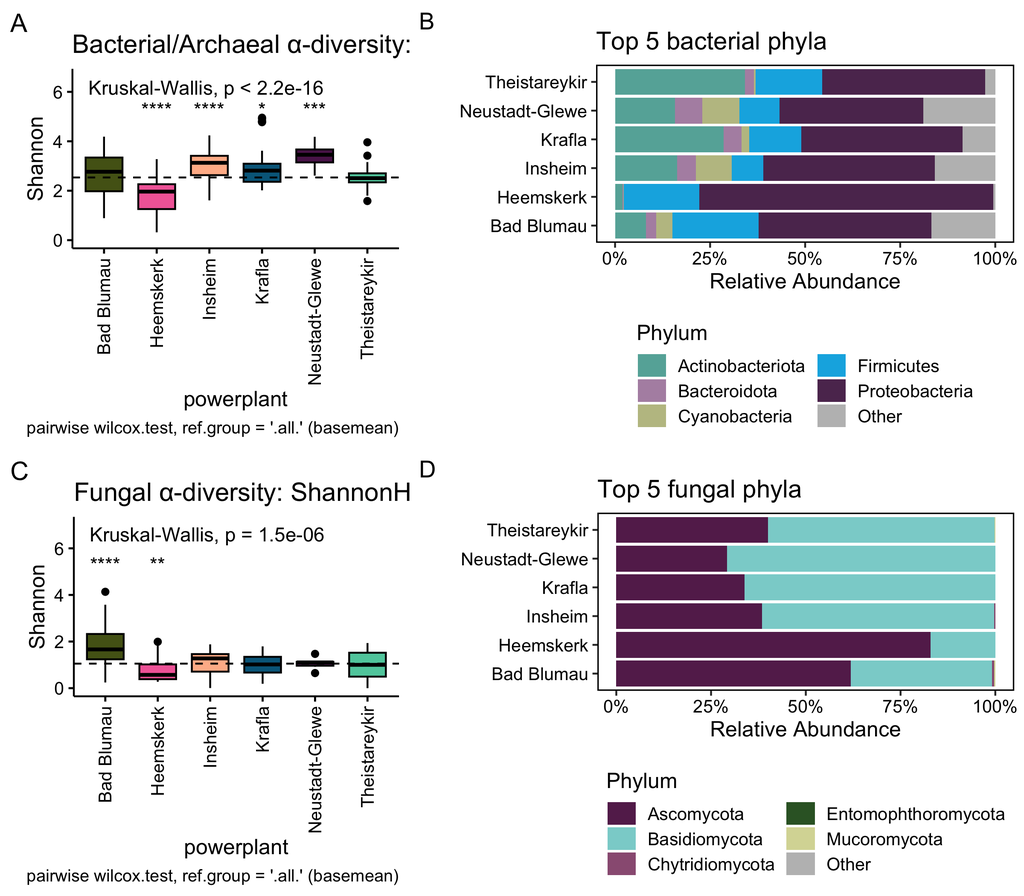

# 2 Figure 2 (ordination/NMDS)

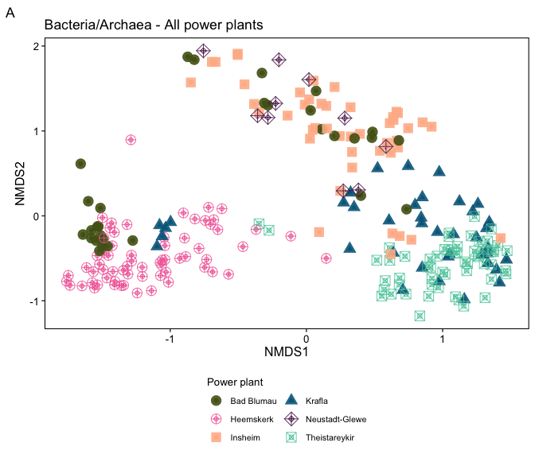

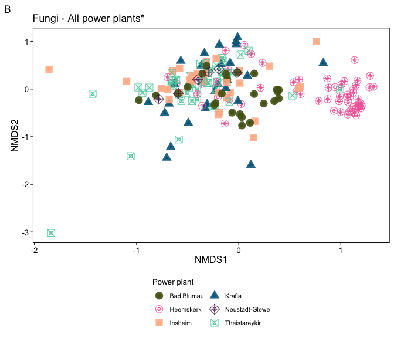

Fig2-caption: NMDS plots showing variation in the abundance-weighted composition of A) bacteria and archaeal and B) fungal communities in relation to the respective power plant origin. NMDS plots based on Bray-Curtis dissimilarities of bacterial and archaeal data: k = 6, 2-dimensional stress = 0.083, non-metric fit R<sup>2</sup> = 0.993, linear fit R<sup>2</sup> = 0.940; fungal data: k = 6, 2-dimensional stress = 0.085, non-metric fit R<sup>2</sup> = 0.993, linear fit R<sup>2</sup> = 0.934. *The fungal ordination has the 2 disconnected samples removed (X243 & X254), in addition to 2 samples that heavily skewed the plot (X100 & X229) [briefly looked for reason why - I believe they have the lowest diversity…]

# 3 Genus-level taxonomy figures per well and per treatment separated by power plant

Question: is “well” the “site” or “type” in the sample data? These graphs are made using the “type” metadata column. This can be easily changed if needed :)

Also: (also re-coding `type` metadata column to match the manuscript: `direct` = “Total”, & `spores` = “Lysis-resistant”)

## 3.1 Genus-level taxonomy tables and figures

**“Global”** is all samples pooled (table only)

**“All Samples”** has sample-level data (relative abundance with taxonomy for all samples & figure with the vertical panels Well and Treatment)

**“By Powerplant”** has relative abundance tables and figures for Well and Treatment, separated by powerplant

### 3.1.1 Global (table of genus-level taxonomy for all samples pooled together)

#### 3.1.1.1 Bacteria/archaea (16S)

(all samples merged by averaging)

| Bac_OTU | Domain | Phylum | Class | Order | Family | Genus | Mean rel abund (%) | Rank_RA (max 530) | Percentile |
| --- | --- | --- | --- | --- | --- | --- | --- | --- | --- |
| OTU1 | Bacteria | Proteobacteria | Gammaproteobacteria | Pseudomonadales | Pseudomonadaceae | Pseudomonas | 18 | 1 | 0 |
| OTU4 | Bacteria | Proteobacteria | Gammaproteobacteria | Burkholderiales | Burkholderiaceae | Ralstonia | 7.2 | 2 | 0.09115770282588878 |
| OTU2 | Bacteria | Proteobacteria | Alphaproteobacteria | Sphingomonadales | Sphingomonadaceae | Sphingomonas | 6.8 | 3 | 0.1823154056517776 |
| OTU3 | Bacteria | Actinobacteriota | Actinobacteria | Pseudonocardiales | Pseudonocardiaceae | Prauserella | 4.9 | 4 | 0.2734731084776664 |
| OTU5 | Bacteria | Actinobacteriota | Rubrobacteria | Rubrobacterales | Rubrobacteriaceae | Rubrobacter | 4.1 | 5 | 0.3646308113035551 |
| OTU13 | Bacteria | Proteobacteria | Gammaproteobacteria | Xanthomonadales | Xanthomonadaceae | Stenotrophomonas | 3.5 | 6 | 0.4557885141294439 |
| OTU14 | Bacteria | Firmicutes | Bacilli | Bacillales | Marinococcaceae | uncl_Marinococcaceae | 2.9 | 7 | 0.5469462169553327 |
| OTU12 | Bacteria | Cyanobacteria | Cyanobacteriia | Cyanobacteriales | Phormidiaceae | Planktothrix_NIVA-CYA_15 | 2.7 | 8 | 0.6381039197812215 |
| OTU9 | Bacteria | Proteobacteria | Gammaproteobacteria | Burkholderiales | Comamonadaceae | Pelomonas | 2.5 | 9 | 0.7292616226071102 |
| OTU8 | Bacteria | Firmicutes | Bacilli | Brevibacillales | Brevibacillaceae | Brevibacillus | 2 | 10 | 0.8204193254329991 |

[output cut: 1088 more lines]

[taxa plot not made, although I can make one figure with the average composition of each powerplant x well x treatment]

#### 3.1.1.2 Fungi (ITS)

note: all rarefied fungal samples included (disconnected samples and outliers not removed)

(all samples merged by averaging)

| Fun_OTU | Domain | Phylum | Class | Order | Family | Genus | Mean rel abund (%) | Rank_RA (max 200) | Percentile |
| --- | --- | --- | --- | --- | --- | --- | --- | --- | --- |
| OTU7 | Fungi | Basidiomycota | Malasseziomycetes | Malasseziales | Malasseziaceae | Malassezia | 23 | 1 | 0 |
| OTU1 | Fungi | Ascomycota | Eurotiomycetes | Eurotiales | Aspergillaceae | Penicillium | 20 | 2 | 0.364963503649635 |
| OTU9 | Fungi | Basidiomycota | Agaricomycetes | Agaricales | Agaricaceae | Agaricus | 4 | 3 | 0.7299270072992701 |
| OTU23 | Fungi | Ascomycota | Eurotiomycetes | Eurotiales | Aspergillaceae | Aspergillus | 3.2 | 4 | 1.094890510948905 |
| OTU14 | Fungi | Ascomycota | Leotiomycetes | uncl_Leotiomycetes | uncl_Leotiomycetes | uncl_Leotiomycetes | 2.6 | 5 | 1.45985401459854 |
| OTU27 | Fungi | Ascomycota | Eurotiomycetes | Eurotiales | Aspergillaceae | uncl_Aspergillaceae | 2.4 | 6 | 1.824817518248175 |
| OTU8 | Fungi | Basidiomycota | Tremellomycetes | Tremellales | Bulleribasidiaceae | Dioszegia | 2.4 | 7 | 2.18978102189781 |
| OTU11 | Fungi | Basidiomycota | Malasseziomycetes | Malasseziales | Malasseziaceae | uncl_Malasseziaceae | 2.4 | 8 | 2.554744525547445 |
| OTU48 | Fungi | Ascomycota | Dothideomycetes | Pleosporales | uncl_Pleosporales | uncl_Pleosporales | 2 | 9 | 2.91970802919708 |
| OTU19 | Fungi | Ascomycota | Saccharomycetes | Saccharomycetales | Debaryomycetaceae | Debaryomyces | 1.7 | 10 | 3.284671532846716 |

[output cut: 265 more lines]

[taxa plot not made, although I can make one figure with the average composition of each powerplant x well x treatment]

### 3.1.2 All Samples

#### 3.1.2.1 Bacteria/archaea (16S)

*File with 16S SILVA OTU relative abundance with taxonomy included for all samples:*

**“DB_16S_SILVA_otu_relativeabundance_ALLSAMPLES_with_taxonomy_Dec2024.csv”**

Figure: each sample is shown, separated by vertical facets of Well and Treatment. X-axis has samples labeled by powerplant_depth_temperature_pair#. Relative abundances of all genera present in these samples were averaged globally, with the top 9 genera present shown, and all other genera not in this sample set’s top 9 were combined into the “Other” category. Note: samples without a corresponding kingdom (ITS) mate have not been removed for taxonomy relative abundance figures.

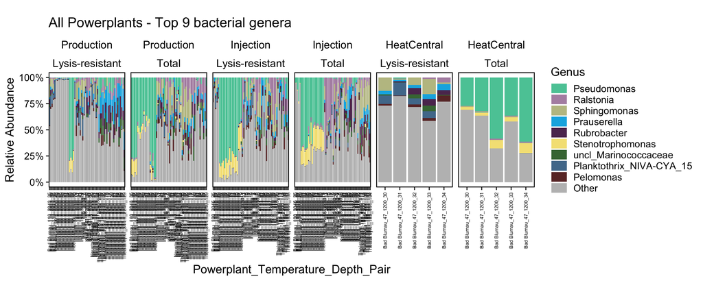

#### 3.1.2.2 Fungi (ITS)

*File with ITS UNITE OTU relative abundance with taxonomy included for all samples:*

**“DB_ITS_UNITE_otu_relativeabundance_ALLSAMPLES_with_taxonomy_Dec2024.csv”**

Figure: each sample is shown, separated by vertical facets of Well and Treatment. X-axis has samples labeled by powerplant_depth_temperature_pair#. Relative abundances of all genera present in these samples were averaged globally, with the top 9 genera present shown, and all other genera not in this sample set’s top 9 were combined into the “Other” category. Note: samples without a corresponding kingdom (16S) mate have not been removed for taxonomy relative abundance figures.

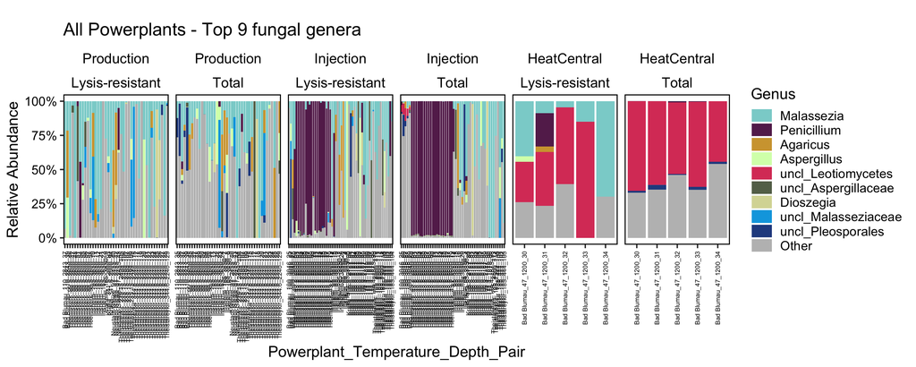

### 3.1.3 By Powerplant

#### 3.1.3.1 Bacteria/archaea (16S)

**Tables**: **a)** Basic table with mean relative abundance of top 9 genera across all samples within each powerplant and **b)** Searchable tables with mean relative abundances of all genera across all samples within each powerplant.

**Figure**: **c)** Each sample is shown, separated by vertical facets of Well and Treatment. X-axis has samples labeled by powerplant_depth_temperature_pair#. Relative abundances of all genera present in these samples were averaged globally, with the top 9 genera present shown, and all other genera not in this sample set’s top 9 were combined into the “Other” category. Note: samples without a corresponding kingdom (ITS) mate have not been removed for taxonomy relative abundance figures.

##### 3.1.3.1.1 Bad Blumau

###### Tables (a & b)

**a) Average relative abundance of top 9 genera across all samples within powerplant Bad Blumau**

```r
  kbl(Bac.Genus.names.to.plot_BadBlumau_byPairTempDepthA[,1:2],
      digits = 2) %>%
  kable_styling(bootstrap_options = c(
    "striped", "hover", "condensed", "responsive"),
    full_width = F, position = "left")
```

| Genus | mean |
| --- | --- |
| Pseudomonas | 21.87 |
| uncl_Desulfofundulus | 11.21 |
| Allorhizobium-Neorhizobium-Pararhizobium-Rhizobium | 5.59 |
| Planktothrix_NIVA-CYA_15 | 3.90 |
| BRH-c8a | 3.83 |
| Sphingomonas | 3.52 |
| Fervidobacterium | 3.50 |
| Stenotrophomonas | 3.45 |
| Pseudothermotoga | 3.17 |

**b) Searchable relative abundance table of genera across all samples within powerplant Bad Blumau**

| Bac_OTU | Domain | Phylum | Class | Order | Family | Genus | Mean rel abund (%) | Rank_RA (max 214) | Percentile |
| --- | --- | --- | --- | --- | --- | --- | --- | --- | --- |
| OTU1 | Bacteria | Proteobacteria | Gammaproteobacteria | Pseudomonadales | Pseudomonadaceae | Pseudomonas | 22 | 1 | 0 |
| OTU15 | Bacteria | Firmicutes | Desulfotomaculia | Desulfotomaculales | Desulfofundulus | uncl_Desulfofundulus | 11 | 2 | 0.2364066193853428 |
| OTU6 | Bacteria | Proteobacteria | Alphaproteobacteria | Rhizobiales | Rhizobiaceae | Allorhizobium-Neorhizobium-Pararhizobium-Rhizobium | 5.6 | 3 | 0.4728132387706856 |
| OTU12 | Bacteria | Cyanobacteria | Cyanobacteriia | Cyanobacteriales | Phormidiaceae | Planktothrix_NIVA-CYA_15 | 3.9 | 4 | 0.7092198581560284 |
| OTU23 | Bacteria | Firmicutes | Desulfotomaculia | Desulfotomaculales | Desulfallas-Sporotomaculum | BRH-c8a | 3.8 | 5 | 0.9456264775413712 |
| OTU2 | Bacteria | Proteobacteria | Alphaproteobacteria | Sphingomonadales | Sphingomonadaceae | Sphingomonas | 3.5 | 6 | 1.182033096926714 |
| OTU29 | Bacteria | Thermotogota | Thermotogae | Thermotogales | Fervidobacteriaceae | Fervidobacterium | 3.5 | 7 | 1.418439716312057 |
| OTU1964 | Bacteria | Proteobacteria | Gammaproteobacteria | Xanthomonadales | Xanthomonadaceae | Stenotrophomonas | 3.5 | 8 | 1.654846335697399 |
| OTU34 | Bacteria | Thermotogota | Thermotogae | Thermotogales | Thermotogaceae | Pseudothermotoga | 3.2 | 9 | 1.891252955082742 |
| OTU62 | Bacteria | Firmicutes | uncl_Firmicutes | uncl_Firmicutes | uncl_Firmicutes | uncl_Firmicutes | 2 | 10 | 2.127659574468085 |

[output cut: 414 more lines]

###### Figure (c)

**c) Figure**: each sample from powerplant **Bad Blumau** is shown, separated by vertical facets of Well and Treatment. X-axis has samples labeled by powerplant_depth_temperature_pair#.

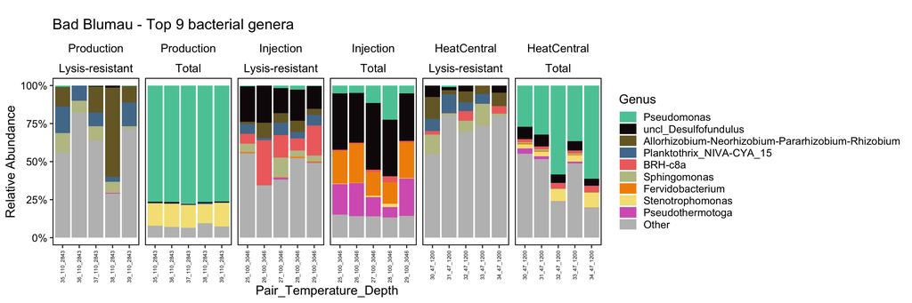

##### 3.1.3.1.2 Heemskerk

###### Tables (a & b)

**a) Average relative abundance of top 9 genera across all samples within powerplant Heemskerk**

```r
  kbl(Bac.Genus.names.to.plot_Heemskerk_byPairTempDepthA[,1:2],
      digits = 2) %>%
  kable_styling(bootstrap_options = c(
    "striped", "hover", "condensed", "responsive"),
    full_width = F, position = "left")
```

| Genus | mean |
| --- | --- |
| Pseudomonas | 52.34 |
| Stenotrophomonas | 11.28 |
| Brevibacillus | 7.70 |
| Bacillus | 6.19 |
| Paenibacillus | 4.31 |
| Allorhizobium-Neorhizobium-Pararhizobium-Rhizobium | 3.50 |
| Comamonas | 1.98 |
| Reyranella | 1.65 |
| uncl_Xanthobacteraceae | 1.46 |

**b) Searchable relative abundance table of genera across all samples within powerplant Heemskerk**

| Bac_OTU | Domain | Phylum | Class | Order | Family | Genus | Mean rel abund (%) | Rank_RA (max 136) | Percentile |
| --- | --- | --- | --- | --- | --- | --- | --- | --- | --- |
| OTU1 | Bacteria | Proteobacteria | Gammaproteobacteria | Pseudomonadales | Pseudomonadaceae | Pseudomonas | 52 | 1 | 0 |
| OTU13 | Bacteria | Proteobacteria | Gammaproteobacteria | Xanthomonadales | Xanthomonadaceae | Stenotrophomonas | 11 | 2 | 0.1642036124794745 |
| OTU8 | Bacteria | Firmicutes | Bacilli | Brevibacillales | Brevibacillaceae | Brevibacillus | 7.7 | 3 | 0.3284072249589491 |
| OTU16 | Bacteria | Firmicutes | Bacilli | Bacillales | Bacillaceae | Bacillus | 6.2 | 4 | 0.4926108374384237 |
| OTU30 | Bacteria | Firmicutes | Bacilli | Paenibacillales | Paenibacillaceae | Paenibacillus | 4.3 | 5 | 0.6568144499178982 |
| OTU6 | Bacteria | Proteobacteria | Alphaproteobacteria | Rhizobiales | Rhizobiaceae | Allorhizobium-Neorhizobium-Pararhizobium-Rhizobium | 3.5 | 6 | 0.8210180623973727 |
| OTU36 | Bacteria | Proteobacteria | Gammaproteobacteria | Burkholderiales | Comamonadaceae | Comamonas | 2 | 7 | 0.9852216748768473 |
| OTU24 | Bacteria | Proteobacteria | Alphaproteobacteria | Reyranellales | Reyranellaceae | Reyranella | 1.6 | 8 | 1.149425287356322 |
| OTU33 | Bacteria | Proteobacteria | Alphaproteobacteria | Rhizobiales | Xanthobacteraceae | uncl_Xanthobacteraceae | 1.5 | 9 | 1.313628899835796 |
| OTU4 | Bacteria | Proteobacteria | Gammaproteobacteria | Burkholderiales | Burkholderiaceae | Ralstonia | 1.2 | 10 | 1.477832512315271 |

[output cut: 600 more lines]

###### Figure (c)

**Figure**: each sample from powerplant **Heemskerk** is shown, separated by vertical facets of Well and Treatment. X-axis has samples labeled by powerplant_depth_temperature_pair#.

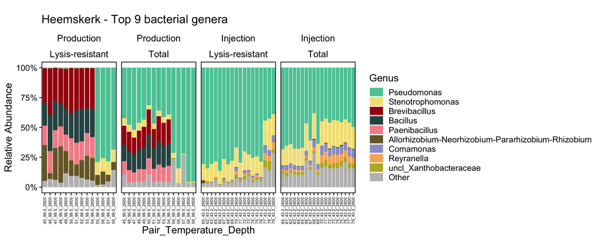

##### 3.1.3.1.3 Insheim

###### Tables (a & b)

**a) Average relative abundance of top 9 genera across all samples within powerplant Insheim**

```r
  kbl(Bac.Genus.names.to.plot_Insheim_byPairTempDepthA[,1:2],
      digits = 2) %>%
  kable_styling(bootstrap_options = c(
    "striped", "hover", "condensed", "responsive"),
    full_width = F, position = "left")
```

| Genus | mean |
| --- | --- |
| Ralstonia | 15.57 |
| Sphingomonas | 10.76 |
| Planktothrix_NIVA-CYA_15 | 8.70 |
| Staphylococcus | 3.44 |
| Prauserella | 3.38 |
| Pelomonas | 3.33 |
| hgcI_clade | 2.95 |
| CL500-29_marine_group | 2.82 |
| uncl_Phycisphaerae | 2.50 |

**b) Searchable relative abundance table of genera across all samples within powerplant Insheim**

| Bac_OTU | Domain | Phylum | Class | Order | Family | Genus | Mean rel abund (%) | Rank_RA (max 293) | Percentile |
| --- | --- | --- | --- | --- | --- | --- | --- | --- | --- |
| OTU4 | Bacteria | Proteobacteria | Gammaproteobacteria | Burkholderiales | Burkholderiaceae | Ralstonia | 16 | 1 | 0 |
| OTU2 | Bacteria | Proteobacteria | Alphaproteobacteria | Sphingomonadales | Sphingomonadaceae | Sphingomonas | 11 | 2 | 0.2169197396963124 |
| OTU12 | Bacteria | Cyanobacteria | Cyanobacteriia | Cyanobacteriales | Phormidiaceae | Planktothrix_NIVA-CYA_15 | 8.7 | 3 | 0.4338394793926247 |
| OTU18 | Bacteria | Firmicutes | Bacilli | Staphylococcales | Staphylococcaceae | Staphylococcus | 3.4 | 4 | 0.6507592190889371 |
| OTU3 | Bacteria | Actinobacteriota | Actinobacteria | Pseudonocardiales | Pseudonocardiaceae | Prauserella | 3.4 | 5 | 0.8676789587852495 |
| OTU9 | Bacteria | Proteobacteria | Gammaproteobacteria | Burkholderiales | Comamonadaceae | Pelomonas | 3.3 | 6 | 1.084598698481562 |
| OTU50 | Bacteria | Actinobacteriota | Actinobacteria | Frankiales | Sporichthyaceae | hgcI_clade | 2.9 | 7 | 1.301518438177874 |
| OTU61 | Bacteria | Actinobacteriota | Acidimicrobiia | Microtrichales | Ilumatobacteraceae | CL500-29_marine_group | 2.8 | 8 | 1.518438177874186 |
| OTU26 | Bacteria | Planctomycetota | Phycisphaerae | uncl_Phycisphaerae | uncl_Phycisphaerae | uncl_Phycisphaerae | 2.5 | 9 | 1.735357917570499 |
| OTU5 | Bacteria | Actinobacteriota | Rubrobacteria | Rubrobacterales | Rubrobacteriaceae | Rubrobacter | 2.4 | 10 | 1.952277657266811 |

[output cut: 452 more lines]

###### Figure (c)

**Figure**: each sample from powerplant **Insheim** is shown, separated by vertical facets of Well and Treatment. X-axis has samples labeled by powerplant_depth_temperature_pair#.

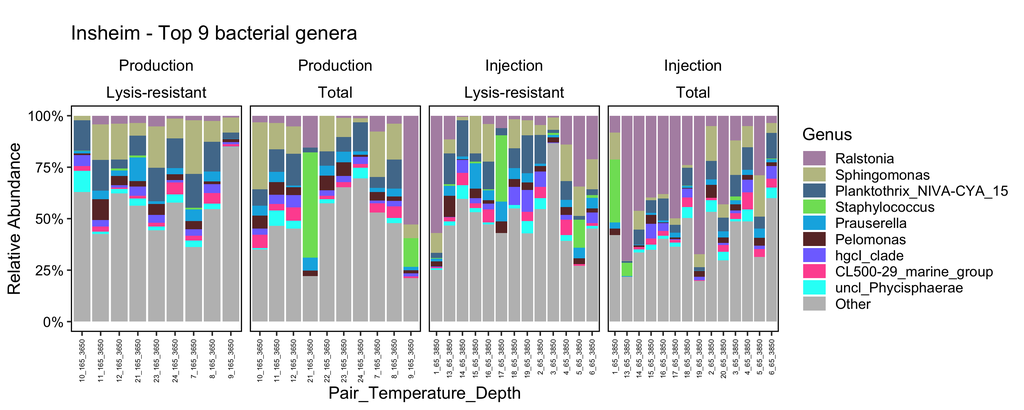

##### 3.1.3.1.4 Krafla

###### Tables (a & b)

**a) Average relative abundance of top 9 genera across all samples within powerplant Krafla**

```r
  kbl(Bac.Genus.names.to.plot_Krafla_byPairTempDepthA[,1:2],
      digits = 2) %>%
  kable_styling(bootstrap_options = c(
    "striped", "hover", "condensed", "responsive"),
    full_width = F, position = "left")
```

| Genus | mean |
| --- | --- |
| Sphingomonas | 11.51 |
| Ralstonia | 8.23 |
| Prauserella | 7.93 |
| Rubrobacter | 7.57 |
| uncl_Marinococcaceae | 4.71 |
| Pelomonas | 4.60 |
| Staphylococcus | 2.83 |
| Cutibacterium | 2.67 |
| Kocuria | 2.11 |

**b) Searchable relative abundance table of genera across all samples within powerplant Krafla**

| Bac_OTU | Domain | Phylum | Class | Order | Family | Genus | Mean rel abund (%) | Rank_RA (max 303) | Percentile |
| --- | --- | --- | --- | --- | --- | --- | --- | --- | --- |
| OTU2 | Bacteria | Proteobacteria | Alphaproteobacteria | Sphingomonadales | Sphingomonadaceae | Sphingomonas | 12 | 1 | 0 |
| OTU10 | Bacteria | Proteobacteria | Gammaproteobacteria | Burkholderiales | Burkholderiaceae | Ralstonia | 8.2 | 2 | 0.1855287569573284 |
| OTU3 | Bacteria | Actinobacteriota | Actinobacteria | Pseudonocardiales | Pseudonocardiaceae | Prauserella | 7.9 | 3 | 0.3710575139146568 |
| OTU5 | Bacteria | Actinobacteriota | Rubrobacteria | Rubrobacterales | Rubrobacteriaceae | Rubrobacter | 7.6 | 4 | 0.5565862708719851 |
| OTU14 | Bacteria | Firmicutes | Bacilli | Bacillales | Marinococcaceae | uncl_Marinococcaceae | 4.7 | 5 | 0.7421150278293136 |
| OTU9 | Bacteria | Proteobacteria | Gammaproteobacteria | Burkholderiales | Comamonadaceae | Pelomonas | 4.6 | 6 | 0.927643784786642 |
| OTU18 | Bacteria | Firmicutes | Bacilli | Staphylococcales | Staphylococcaceae | Staphylococcus | 2.8 | 7 | 1.11317254174397 |
| OTU7 | Bacteria | Actinobacteriota | Actinobacteria | Propionibacteriales | Propionibacteriaceae | Cutibacterium | 2.7 | 8 | 1.298701298701299 |
| OTU11 | Bacteria | Actinobacteriota | Actinobacteria | Micrococcales | Micrococcaceae | Kocuria | 2.1 | 9 | 1.484230055658627 |
| OTU1 | Bacteria | Proteobacteria | Gammaproteobacteria | Pseudomonadales | Pseudomonadaceae | Pseudomonas | 1.9 | 10 | 1.669758812615955 |

[output cut: 530 more lines]

###### Figure (c)

**Figure**: each sample from powerplant **Krafla** is shown, separated by vertical facets of Well and Treatment. X-axis has samples labeled by powerplant_depth_temperature_pair#.

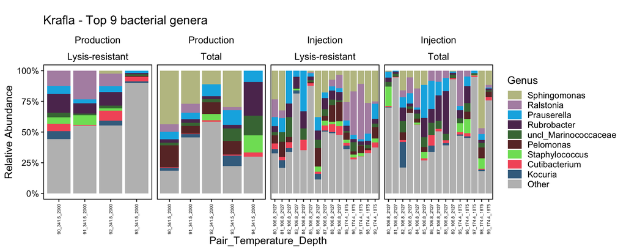

##### 3.1.3.1.5 Neustadt-Glewe

###### Tables (a & b)

**a) Average relative abundance of top 9 genera across all samples within powerplant Neustadt-Glewe**

```r
kbl(Bac.Genus.names.to.plot_NeustadtGlewe_byPairTempDepthA[,1:2],
      digits = 2) %>%
  kable_styling(bootstrap_options = c(
    "striped", "hover", "condensed", "responsive"),
    full_width = F, position = "left")
```

| Genus | mean |
| --- | --- |
| Planktothrix_NIVA-CYA_15 | 8.78 |
| Pseudomonas | 7.72 |
| Sphingomonas | 7.08 |
| Allorhizobium-Neorhizobium-Pararhizobium-Rhizobium | 5.03 |
| CL500-29_marine_group | 3.65 |
| Anoxybacillus | 3.47 |
| hgcI_clade | 2.92 |
| uncl_Phycisphaerae | 2.86 |
| Pelomonas | 2.77 |

**b) Searchable relative abundance table of genera across all samples within powerplant Neustadt-Glewe**

| Bac_OTU | Domain | Phylum | Class | Order | Family | Genus | Mean rel abund (%) | Rank_RA (max 165) | Percentile |
| --- | --- | --- | --- | --- | --- | --- | --- | --- | --- |
| OTU12 | Bacteria | Cyanobacteria | Cyanobacteriia | Cyanobacteriales | Phormidiaceae | Planktothrix_NIVA-CYA_15 | 8.8 | 1 | 0 |
| OTU1 | Bacteria | Proteobacteria | Gammaproteobacteria | Pseudomonadales | Pseudomonadaceae | Pseudomonas | 7.7 | 2 | 0.4201680672268908 |
| OTU2 | Bacteria | Proteobacteria | Alphaproteobacteria | Sphingomonadales | Sphingomonadaceae | Sphingomonas | 7.1 | 3 | 0.8403361344537815 |
| OTU6 | Bacteria | Proteobacteria | Alphaproteobacteria | Rhizobiales | Rhizobiaceae | Allorhizobium-Neorhizobium-Pararhizobium-Rhizobium | 5 | 4 | 1.260504201680672 |
| OTU61 | Bacteria | Actinobacteriota | Acidimicrobiia | Microtrichales | Ilumatobacteraceae | CL500-29_marine_group | 3.6 | 5 | 1.680672268907563 |
| OTU46 | Bacteria | Firmicutes | Bacilli | Bacillales | Bacillaceae | Anoxybacillus | 3.5 | 6 | 2.100840336134454 |
| OTU50 | Bacteria | Actinobacteriota | Actinobacteria | Frankiales | Sporichthyaceae | hgcI_clade | 2.9 | 7 | 2.521008403361344 |
| OTU26 | Bacteria | Planctomycetota | Phycisphaerae | uncl_Phycisphaerae | uncl_Phycisphaerae | uncl_Phycisphaerae | 2.9 | 8 | 2.941176470588235 |
| OTU9 | Bacteria | Proteobacteria | Gammaproteobacteria | Burkholderiales | Comamonadaceae | Pelomonas | 2.8 | 9 | 3.361344537815126 |
| OTU25 | Bacteria | Planctomycetota | uncl_Planctomycetota | uncl_Planctomycetota | uncl_Planctomycetota | uncl_Planctomycetota | 2.6 | 10 | 3.781512605042017 |

[output cut: 229 more lines]

###### Figure (c)

**Figure**: each sample from powerplant **Neustadt-Glewe** is shown, separated by vertical facets of Well and Treatment. X-axis has samples labeled by powerplant_depth_temperature_pair#.

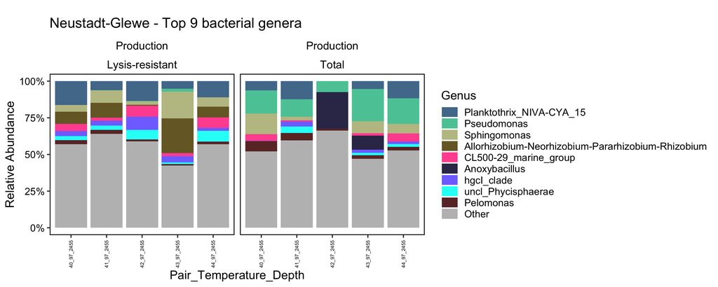

##### 3.1.3.1.6 Theistareykir

###### Tables (a & b)

**a) Average relative abundance of top 9 genera across all samples within powerplant Theistareykir**

```r
kbl(Bac.Genus.names.to.plot_Theistareykir_byPairTempDepthA[,1:2],
      digits = 2) %>%
  kable_styling(bootstrap_options = c(
    "striped", "hover", "condensed", "responsive"),
    full_width = F, position = "left")
```

| Genus | mean |
| --- | --- |
| Prauserella | 11.60 |
| Ralstonia | 10.66 |
| Sphingomonas | 9.26 |
| Rubrobacter | 8.95 |
| uncl_Marinococcaceae | 6.83 |
| Cutibacterium | 4.14 |
| Pseudomonas | 3.98 |
| Pelomonas | 3.92 |
| Acinetobacter | 3.78 |

**b) Searchable relative abundance table of genera across all samples within powerplant Theistareykir**

| Bac_OTU | Domain | Phylum | Class | Order | Family | Genus | Mean rel abund (%) | Rank_RA (max 241) | Percentile |
| --- | --- | --- | --- | --- | --- | --- | --- | --- | --- |
| OTU3 | Bacteria | Actinobacteriota | Actinobacteria | Pseudonocardiales | Pseudonocardiaceae | Prauserella | 12 | 1 | 0 |
| OTU4 | Bacteria | Proteobacteria | Gammaproteobacteria | Burkholderiales | Burkholderiaceae | Ralstonia | 11 | 2 | 0.3257328990228013 |
| OTU2 | Bacteria | Proteobacteria | Alphaproteobacteria | Sphingomonadales | Sphingomonadaceae | Sphingomonas | 9.3 | 3 | 0.6514657980456027 |
| OTU5 | Bacteria | Actinobacteriota | Rubrobacteria | Rubrobacterales | Rubrobacteriaceae | Rubrobacter | 8.9 | 4 | 0.9771986970684038 |
| OTU14 | Bacteria | Firmicutes | Bacilli | Bacillales | Marinococcaceae | uncl_Marinococcaceae | 6.8 | 5 | 1.302931596091205 |
| OTU7 | Bacteria | Actinobacteriota | Actinobacteria | Propionibacteriales | Propionibacteriaceae | Cutibacterium | 4.1 | 6 | 1.628664495114007 |
| OTU1 | Bacteria | Proteobacteria | Gammaproteobacteria | Pseudomonadales | Pseudomonadaceae | Pseudomonas | 4 | 7 | 1.954397394136808 |
| OTU9 | Bacteria | Proteobacteria | Gammaproteobacteria | Burkholderiales | Comamonadaceae | Pelomonas | 3.9 | 8 | 2.280130293159609 |
| OTU32 | Bacteria | Proteobacteria | Gammaproteobacteria | Pseudomonadales | Moraxellaceae | Acinetobacter | 3.8 | 9 | 2.605863192182411 |
| OTU11 | Bacteria | Actinobacteriota | Actinobacteria | Micrococcales | Micrococcaceae | Kocuria | 3.2 | 10 | 2.931596091205212 |

[output cut: 298 more lines]

###### Figure (c)

**Figure**: each sample from powerplant **Theistareykir** is shown, separated by vertical facets of Well and Treatment. X-axis has samples labeled by powerplant_depth_temperature_pair#.

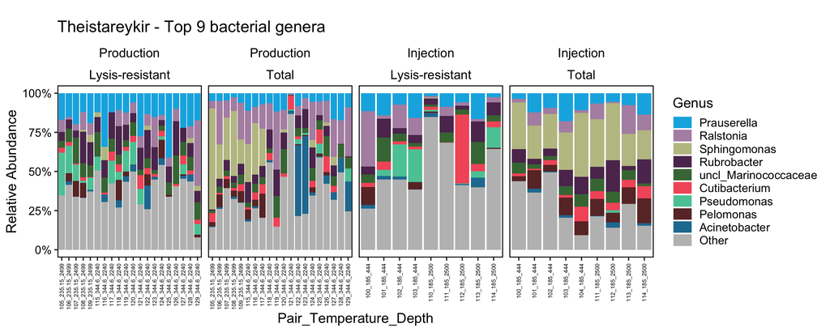

#### 3.1.3.2 Fungi (ITS)

**Tables**: **a)** Basic table with mean relative abundance of top 9 genera across all samples within each powerplant and **b)** Searchable tables with mean relative abundances of all genera across all samples within each powerplant.

##### 3.1.3.2.1 Bad Blumau

###### Tables (a & b)

**a) Average relative abundance of top 9 genera across all samples within powerplant Bad Blumau**

```r
  kbl(Fun.Genus.names.to.plot_BadBlumau_byPairTempDepthA[,1:2],
      digits = 2) %>%
  kable_styling(bootstrap_options = c(
    "striped", "hover", "condensed", "responsive"),
    full_width = F, position = "left")
```

| Genus | mean |
| --- | --- |
| uncl_Leotiomycetes | 21.02 |
| Malassezia | 16.13 |
| uncl_Pleosporales | 7.80 |
| Rhodotorula | 5.59 |
| uncl_Sordariomycetes | 4.80 |
| Agaricus | 3.59 |
| Exophiala | 3.35 |
| uncl_Ascomycota | 2.27 |
| Aspergillus | 2.06 |

**b) Searchable relative abundance table of genera across all samples within powerplant Bad Blumau**

| Fun_OTU | Domain | Phylum | Class | Order | Family | Genus | Mean rel abund (%) | Rank_RA (max 103) | Percentile |
| --- | --- | --- | --- | --- | --- | --- | --- | --- | --- |
| OTU14 | Fungi | Ascomycota | Leotiomycetes | uncl_Leotiomycetes | uncl_Leotiomycetes | uncl_Leotiomycetes | 21 | 1 | 0 |
| OTU7 | Fungi | Basidiomycota | Malasseziomycetes | Malasseziales | Malasseziaceae | Malassezia | 16 | 2 | 0.5524861878453038 |
| OTU48 | Fungi | Ascomycota | Dothideomycetes | Pleosporales | uncl_Pleosporales | uncl_Pleosporales | 7.8 | 3 | 1.104972375690608 |
| OTU18 | Fungi | Basidiomycota | Microbotryomycetes | Sporidiobolales | Sporidiobolaceae | Rhodotorula | 5.6 | 4 | 1.657458563535912 |
| OTU40 | Fungi | Ascomycota | Sordariomycetes | uncl_Sordariomycetes | uncl_Sordariomycetes | uncl_Sordariomycetes | 4.8 | 5 | 2.209944751381215 |
| OTU9 | Fungi | Basidiomycota | Agaricomycetes | Agaricales | Agaricaceae | Agaricus | 3.6 | 6 | 2.762430939226519 |
| OTU74 | Fungi | Ascomycota | Eurotiomycetes | Chaetothyriales | Herpotrichiellaceae | Exophiala | 3.3 | 7 | 3.314917127071823 |
| OTU86 | Fungi | Ascomycota | uncl_Ascomycota | uncl_Ascomycota | uncl_Ascomycota | uncl_Ascomycota | 2.3 | 8 | 3.867403314917127 |
| OTU23 | Fungi | Ascomycota | Eurotiomycetes | Eurotiales | Aspergillaceae | Aspergillus | 2.1 | 9 | 4.41988950276243 |
| OTU51 | Fungi | Ascomycota | Dothideomycetes | Pleosporales | Pleosporaceae | Stemphylium | 1.9 | 10 | 4.972375690607735 |

[output cut: 172 more lines]

###### Figure (c)

**c) Figure**: each sample from powerplant **Bad Blumau** is shown, separated by vertical facets of Well and Treatment. X-axis has samples labeled by powerplant_depth_temperature_pair#.

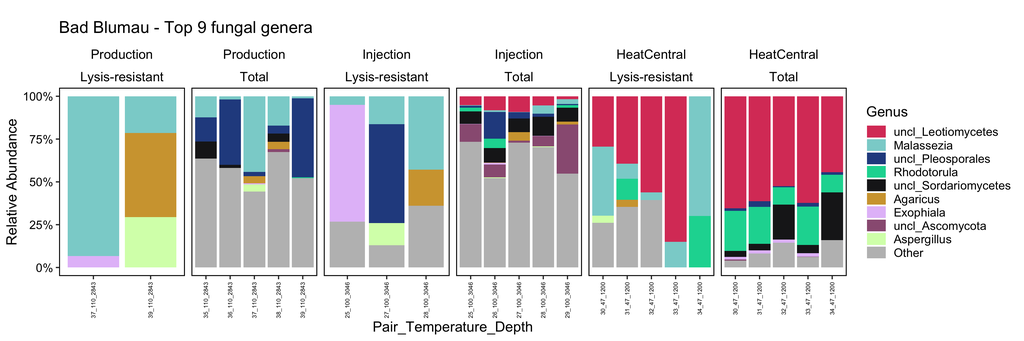

##### 3.1.3.2.2 Heemskerk

###### Tables (a & b)

**a) Average relative abundance of top 9 genera across all samples within powerplant Heemskerk**

```r
  kbl(Fun.Genus.names.to.plot_Heemskerk_byPairTempDepthA[,1:2],
      digits = 2) %>%
  kable_styling(bootstrap_options = c(
    "striped", "hover", "condensed", "responsive"),
    full_width = F, position = "left")
```

| Genus | mean |
| --- | --- |
| Penicillium | 65.60 |
| Malassezia | 10.72 |
| Cyberlindnera | 1.76 |
| Papiliotrema | 1.58 |
| uncl_Aspergillaceae | 1.57 |
| Aspergillus | 1.27 |
| uncl_Helotiales | 1.27 |
| Debaryomyces | 1.21 |
| uncl_Eurotiomycetes | 1.02 |

**b) Searchable relative abundance table of genera across all samples within powerplant Heemskerk**

| Fun_OTU | Domain | Phylum | Class | Order | Family | Genus | Mean rel abund (%) | Rank_RA (max 67) | Percentile |
| --- | --- | --- | --- | --- | --- | --- | --- | --- | --- |
| OTU1 | Fungi | Ascomycota | Eurotiomycetes | Eurotiales | Aspergillaceae | Penicillium | 66 | 1 | 0 |
| OTU43 | Fungi | Basidiomycota | Malasseziomycetes | Malasseziales | Malasseziaceae | Malassezia | 11 | 2 | 1.162790697674419 |
| OTU54 | Fungi | Ascomycota | Saccharomycetes | Saccharomycetales | Phaffomycetaceae | Cyberlindnera | 1.8 | 3 | 2.325581395348837 |
| OTU37 | Fungi | Basidiomycota | Tremellomycetes | Tremellales | Rhynchogastremataceae | Papiliotrema | 1.6 | 4 | 3.488372093023256 |
| OTU68 | Fungi | Ascomycota | Eurotiomycetes | Eurotiales | Aspergillaceae | uncl_Aspergillaceae | 1.6 | 5 | 4.651162790697675 |
| OTU23 | Fungi | Ascomycota | Eurotiomycetes | Eurotiales | Aspergillaceae | Aspergillus | 1.3 | 6 | 5.813953488372093 |
| OTU146 | Fungi | Ascomycota | Leotiomycetes | Helotiales | uncl_Helotiales | uncl_Helotiales | 1.3 | 7 | 6.976744186046512 |
| OTU19 | Fungi | Ascomycota | Saccharomycetes | Saccharomycetales | Debaryomycetaceae | Debaryomyces | 1.2 | 8 | 8.13953488372093 |
| OTU315 | Fungi | Ascomycota | Eurotiomycetes | uncl_Eurotiomycetes | uncl_Eurotiomycetes | uncl_Eurotiomycetes | 1 | 9 | 9.30232558139535 |
| OTU120 | Fungi | Ascomycota | Saccharomycetes | Saccharomycetales | Saccharomycetaceae | Saccharomyces | 0.9 | 10 | 10.46511627906977 |

[output cut: 77 more lines]

###### Figure (c)

**c) Figure**: each sample from powerplant **Heemskerk** is shown, separated by vertical facets of Well and Treatment. X-axis has samples labeled by powerplant_depth_temperature_pair#.

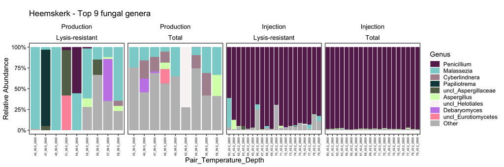

##### 3.1.3.2.3 Insheim

###### Tables (a & b)

**a) Average relative abundance of top 9 genera across all samples within powerplant Insheim**

```r
  kbl(Fun.Genus.names.to.plot_Insheim_byPairTempDepthA[,1:2],
      digits = 2) %>%
  kable_styling(bootstrap_options = c(
    "striped", "hover", "condensed", "responsive"),
    full_width = F, position = "left")
```

| Genus | mean |
| --- | --- |
| Malassezia | 28.80 |
| Agaricus | 13.99 |
| Aspergillus | 6.30 |
| uncl_Malasseziaceae | 4.71 |
| Vishniacozyma | 4.04 |
| Penicillium | 3.89 |
| uncl_Microascales | 3.60 |
| Exophiala | 3.27 |
| uncl_Pleosporales | 3.23 |

**b) Searchable relative abundance table of genera across all samples within powerplant Insheim**

| Fun_OTU | Domain | Phylum | Class | Order | Family | Genus | Mean rel abund (%) | Rank_RA (max 56) | Percentile |
| --- | --- | --- | --- | --- | --- | --- | --- | --- | --- |
| OTU7 | Fungi | Basidiomycota | Malasseziomycetes | Malasseziales | Malasseziaceae | Malassezia | 29 | 1 | 0 |
| OTU9 | Fungi | Basidiomycota | Agaricomycetes | Agaricales | Agaricaceae | Agaricus | 14 | 2 | 1.5625 |
| OTU23 | Fungi | Ascomycota | Eurotiomycetes | Eurotiales | Aspergillaceae | Aspergillus | 6.3 | 3 | 3.125 |
| OTU11 | Fungi | Basidiomycota | Malasseziomycetes | Malasseziales | Malasseziaceae | uncl_Malasseziaceae | 4.7 | 4 | 4.6875 |
| OTU84 | Fungi | Basidiomycota | Tremellomycetes | Tremellales | Bulleribasidiaceae | Vishniacozyma | 4 | 5 | 6.25 |
| OTU10 | Fungi | Ascomycota | Eurotiomycetes | Eurotiales | Aspergillaceae | Penicillium | 3.9 | 6 | 7.8125 |
| OTU38 | Fungi | Ascomycota | Sordariomycetes | Microascales | uncl_Microascales | uncl_Microascales | 3.6 | 7 | 9.375 |
| OTU102 | Fungi | Ascomycota | Eurotiomycetes | Chaetothyriales | Herpotrichiellaceae | Exophiala | 3.3 | 8 | 10.9375 |
| OTU83 | Fungi | Ascomycota | Dothideomycetes | Pleosporales | uncl_Pleosporales | uncl_Pleosporales | 3.2 | 9 | 12.5 |
| OTU19 | Fungi | Ascomycota | Saccharomycetes | Saccharomycetales | Debaryomycetaceae | Debaryomyces | 2.5 | 10 | 14.0625 |

[output cut: 55 more lines]

###### Figure (c)

**c) Figure**: each sample from powerplant **Insheim** is shown, separated by vertical facets of Well and Treatment. X-axis has samples labeled by powerplant_depth_temperature_pair#.

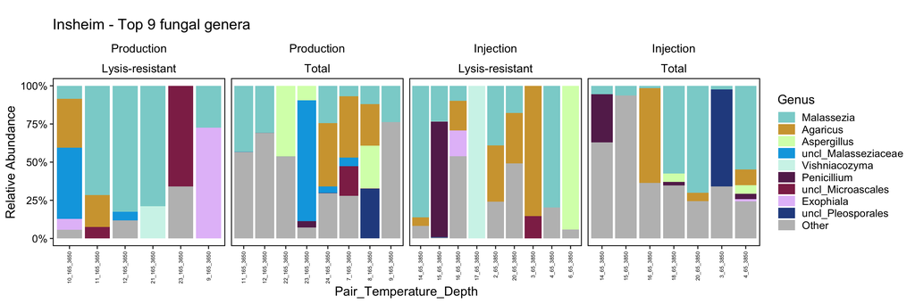

##### 3.1.3.2.4 Krafla

###### Tables (a & b)

**a) Average relative abundance of top 9 genera across all samples within powerplant Krafla**

```r
  kbl(Fun.Genus.names.to.plot_Krafla_byPairTempDepthA[,1:2],
      digits = 2) %>%
  kable_styling(bootstrap_options = c(
    "striped", "hover", "condensed", "responsive"),
    full_width = F, position = "left")
```

| Genus | mean |
| --- | --- |
| Malassezia | 29.64 |
| Dioszegia | 7.21 |
| uncl_Aspergillaceae | 4.94 |
| Aspergillus | 4.44 |
| Rhodotorula | 3.56 |
| uncl_Rickenellaceae | 3.38 |
| Phlebia | 3.18 |
| Coprinopsis | 3.15 |
| Filobasidium | 3.04 |

**b) Searchable relative abundance table of genera across all samples within powerplant Krafla**

| Fun_OTU | Domain | Phylum | Class | Order | Family | Genus | Mean rel abund (%) | Rank_RA (max 48) | Percentile |
| --- | --- | --- | --- | --- | --- | --- | --- | --- | --- |
| OTU43 | Fungi | Basidiomycota | Malasseziomycetes | Malasseziales | Malasseziaceae | Malassezia | 30 | 1 | 0 |
| OTU8 | Fungi | Basidiomycota | Tremellomycetes | Tremellales | Bulleribasidiaceae | Dioszegia | 7.2 | 2 | 2.040816326530612 |
| OTU27 | Fungi | Ascomycota | Eurotiomycetes | Eurotiales | Aspergillaceae | uncl_Aspergillaceae | 4.9 | 3 | 4.081632653061225 |
| OTU23 | Fungi | Ascomycota | Eurotiomycetes | Eurotiales | Aspergillaceae | Aspergillus | 4.4 | 4 | 6.122448979591836 |
| OTU18 | Fungi | Basidiomycota | Microbotryomycetes | Sporidiobolales | Sporidiobolaceae | Rhodotorula | 3.6 | 5 | 8.16326530612245 |
| OTU73 | Fungi | Basidiomycota | Agaricomycetes | Hymenochaetales | Rickenellaceae | uncl_Rickenellaceae | 3.4 | 6 | 10.20408163265306 |
| OTU20 | Fungi | Basidiomycota | Agaricomycetes | Polyporales | Meruliaceae | Phlebia | 3.2 | 7 | 12.24489795918367 |
| OTU123 | Fungi | Basidiomycota | Agaricomycetes | Agaricales | Psathyrellaceae | Coprinopsis | 3.2 | 8 | 14.28571428571428 |
| OTU88 | Fungi | Basidiomycota | Tremellomycetes | Filobasidiales | Filobasidiaceae | Filobasidium | 3 | 9 | 16.3265306122449 |
| OTU17 | Fungi | Ascomycota | Sordariomycetes | Hypocreales | Hypocreaceae | Trichoderma | 2.7 | 10 | 18.36734693877551 |

[output cut: 40 more lines]

###### Figure (c)

**c) Figure**: each sample from powerplant **Krafla** is shown, separated by vertical facets of Well and Treatment. X-axis has samples labeled by powerplant_depth_temperature_pair#.

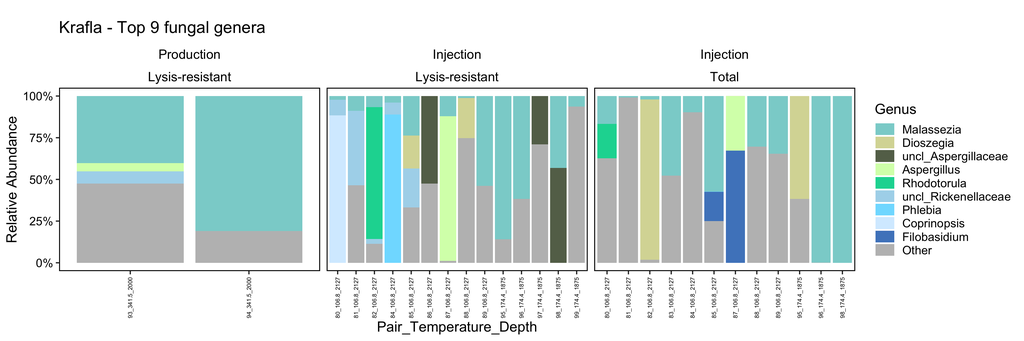

##### 3.1.3.2.5 Neustadt-Glewe

###### Tables (a & b)

**a) Average relative abundance of top 9 genera across all samples within powerplant Neustadt-Glewe**

```r
  kbl(Fun.Genus.names.to.plot_NeustadtGlewe_byPairTempDepthA[,1:2],
      digits = 2) %>%
  kable_styling(bootstrap_options = c(
    "striped", "hover", "condensed", "responsive"),
    full_width = F, position = "left")
```

| Genus | mean |
| --- | --- |
| Malassezia | 30.11 |
| Agaricus | 18.16 |
| Sporidesmium | 10.75 |
| Symmetrospora | 9.89 |
| uncl_Sordariomycetes | 9.54 |
| uncl_Malasseziaceae | 5.36 |
| Penicillium | 5.11 |
| uncl_Basidiomycota | 4.74 |
| Dioszegia | 2.54 |

**b) Searchable relative abundance table of genera across all samples within powerplant Neustadt-Glewe**

| Fun_OTU | Domain | Phylum | Class | Order | Family | Genus | Mean rel abund (%) | Rank_RA (max 12) | Percentile |
| --- | --- | --- | --- | --- | --- | --- | --- | --- | --- |
| OTU7 | Fungi | Basidiomycota | Malasseziomycetes | Malasseziales | Malasseziaceae | Malassezia | 30 | 1 | 0 |
| OTU9 | Fungi | Basidiomycota | Agaricomycetes | Agaricales | Agaricaceae | Agaricus | 18 | 2 | 9.090909090909092 |
| OTU137 | Fungi | Ascomycota | Sordariomycetes | Sporidesmiales | Sporidesmiaceae | Sporidesmium | 11 | 3 | 18.18181818181818 |
| OTU193 | Fungi | Basidiomycota | Cystobasidiomycetes | Cystobasidiomycetes_ord_Incertae_sedis | Symmetrosporaceae | Symmetrospora | 9.9 | 4 | 27.27272727272727 |
| OTU28 | Fungi | Ascomycota | Sordariomycetes | uncl_Sordariomycetes | uncl_Sordariomycetes | uncl_Sordariomycetes | 9.5 | 5 | 36.36363636363637 |
| OTU11 | Fungi | Basidiomycota | Malasseziomycetes | Malasseziales | Malasseziaceae | uncl_Malasseziaceae | 5.4 | 6 | 45.45454545454545 |
| OTU10 | Fungi | Ascomycota | Eurotiomycetes | Eurotiales | Aspergillaceae | Penicillium | 5.1 | 7 | 54.54545454545454 |
| OTU129 | Fungi | Basidiomycota | uncl_Basidiomycota | uncl_Basidiomycota | uncl_Basidiomycota | uncl_Basidiomycota | 4.7 | 8 | 63.63636363636363 |
| OTU70 | Fungi | Basidiomycota | Tremellomycetes | Tremellales | Bulleribasidiaceae | Dioszegia | 2.5 | 9 | 72.72727272727273 |
| OTU107 | Fungi | Ascomycota | Eurotiomycetes | Eurotiales | Aspergillaceae | Aspergillus | 2.5 | 10 | 81.81818181818183 |

[output cut: 2 more lines]

###### Figure (c)

**c) Figure**: each sample from powerplant **Neustadt-Glewe** is shown, separated by vertical facets of Well and Treatment. X-axis has samples labeled by powerplant_depth_temperature_pair#.

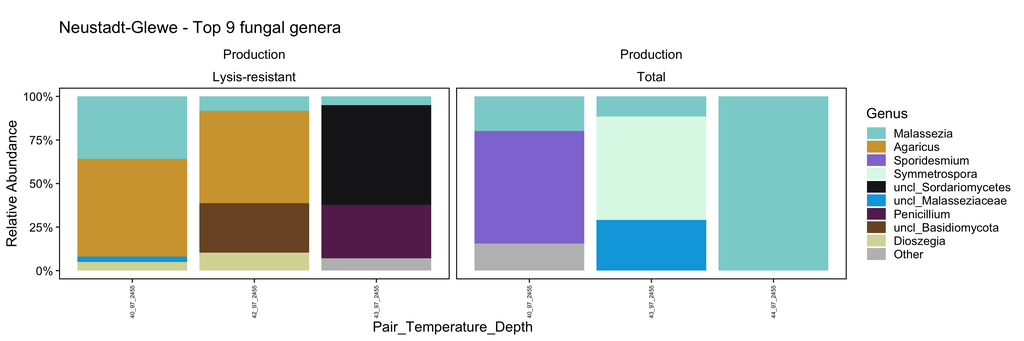

##### 3.1.3.2.6 Theistareykir

###### Tables (a & b)

**a) Average relative abundance of top 9 genera across all samples within powerplant Theistareykir**

```r
  kbl(Fun.Genus.names.to.plot_Theistareykir_byPairTempDepthA[,1:2],
      digits = 2) %>%
  kable_styling(bootstrap_options = c(
    "striped", "hover", "condensed", "responsive"),
    full_width = F, position = "left")
```

| Genus | mean |
| --- | --- |
| Malassezia | 30.35 |
| uncl_Malasseziaceae | 4.60 |
| Dioszegia | 4.55 |
| Aspergillus | 3.42 |
| uncl_Aspergillaceae | 2.89 |
| Debaryomyces | 2.74 |
| Agaricus | 2.48 |
| Trichoderma | 2.37 |
| uncl_Ascomycota | 2.32 |

**b) Searchable relative abundance table of genera across all samples within powerplant Theistareykir**

| Fun_OTU | Domain | Phylum | Class | Order | Family | Genus | Mean rel abund (%) | Rank_RA (max 66) | Percentile |
| --- | --- | --- | --- | --- | --- | --- | --- | --- | --- |
| OTU43 | Fungi | Basidiomycota | Malasseziomycetes | Malasseziales | Malasseziaceae | Malassezia | 30 | 1 | 0 |
| OTU11 | Fungi | Basidiomycota | Malasseziomycetes | Malasseziales | Malasseziaceae | uncl_Malasseziaceae | 4.6 | 2 | 1.470588235294118 |
| OTU8 | Fungi | Basidiomycota | Tremellomycetes | Tremellales | Bulleribasidiaceae | Dioszegia | 4.5 | 3 | 2.941176470588235 |
| OTU23 | Fungi | Ascomycota | Eurotiomycetes | Eurotiales | Aspergillaceae | Aspergillus | 3.4 | 4 | 4.411764705882353 |
| OTU27 | Fungi | Ascomycota | Eurotiomycetes | Eurotiales | Aspergillaceae | uncl_Aspergillaceae | 2.9 | 5 | 5.88235294117647 |
| OTU19 | Fungi | Ascomycota | Saccharomycetes | Saccharomycetales | Debaryomycetaceae | Debaryomyces | 2.7 | 6 | 7.352941176470589 |
| OTU9 | Fungi | Basidiomycota | Agaricomycetes | Agaricales | Agaricaceae | Agaricus | 2.5 | 7 | 8.823529411764707 |
| OTU17 | Fungi | Ascomycota | Sordariomycetes | Hypocreales | Hypocreaceae | Trichoderma | 2.4 | 8 | 10.29411764705882 |
| OTU67 | Fungi | Ascomycota | uncl_Ascomycota | uncl_Ascomycota | uncl_Ascomycota | uncl_Ascomycota | 2.3 | 9 | 11.76470588235294 |
| OTU72 | Fungi | Ascomycota | Dothideomycetes | Pleosporales | Cucurbitariaceae | Pyrenochaetopsis | 2.1 | 10 | 13.23529411764706 |

[output cut: 59 more lines]

###### Figure (c)

**c) Figure**: each sample from powerplant **Theistareykir** is shown, separated by vertical facets of Well and Treatment. X-axis has samples labeled by powerplant_depth_temperature_pair#.

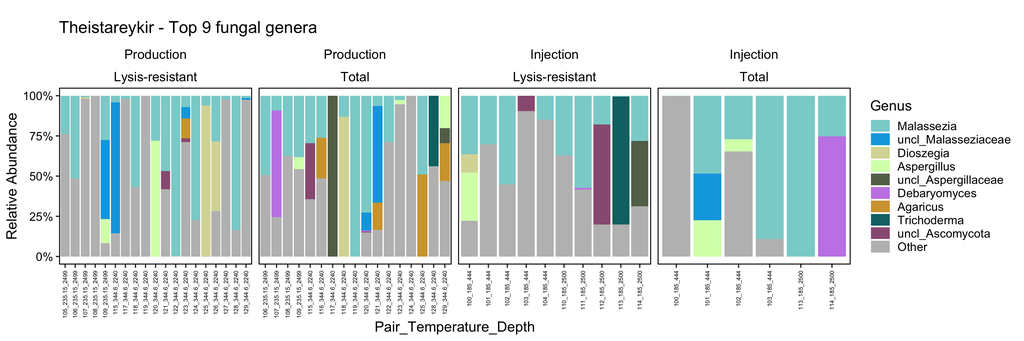

# 4 Additional notes about methods for fungal ordinations

Note about ordinating fungal data: For the unrarefied data, multiple samples have 0 OTUs in common and thus share no overlapping features. Beginning with input OTU table (unrarefied first), it was necessary to prune OTUs with less than 20 observations (dropping # of OTUs from 533 to 481) followed by prune samples with less than 500 reads (dropping # of samples from 258 to 239). These particular values varied after rarefaction but nonetheless resulted disconnected groups of samples/data after converting to bray-curtis distance matrices. Unrarefied data yielded 4 disconnected groups: 236 samples that were amenable to ordination and 3 groups of 1 sample each that were disconnected from all other samples.

```r
# physeqFUN.unrare.prun.t20 <- prune_taxa(taxa_sums(unrare_Fun_noB_min2)>=20, unrare_Fun_noB_min2)
# physeqFUN.unrare.prun.t20.s500 <- prune_samples(sample_sums(physeqFUN.unrare.prun.t20)>=500, physeqFUN.unrare.prun.t20)
FUN.unrare.prun.t20.s500_bray<-phyloseq::distance(physeqFUN.unrare.prun.t20.s500, method="bray", type = "samples")
dc.FUN.unrare.prun.t20.s500_bray<-distconnected(FUN.unrare.prun.t20.s500_bray, toolong = 1, trace = 3)
```

```
## Connectivity of distance matrix with threshold dissimilarity 1
## Data are disconnected: 4 groups
## Groups sizes
##   1   2   3   4
## 236   1   1   1
```

```r
# dc.FUN.unrare.prun.t20.s500_bray[146] #2 "X243"
# dc.FUN.unrare.prun.t20.s500_bray[154] #3 "X251"
# dc.FUN.unrare.prun.t20.s500_bray[157] #4 "X254"
#X229 also appears to be an outlier


# fun_outliers<-c(sample_names(physeqFUN.unrare.prun.t20.s500)[146],sample_names(physeqFUN.unrare.prun.t20.s500)[154],sample_names(physeqFUN.unrare.prun.t20.s500)[157])
```

In the unrarefied data, these disconnected samples were:

```r
#X229 also appears to be an outlier
fun_outliers<-sort(c(sample_names(physeqFUN.unrare.prun.t20.s500)[146],sample_names(physeqFUN.unrare.prun.t20.s500)[154],sample_names(physeqFUN.unrare.prun.t20.s500)[157],"X229","X100"))

# fun_outliers_df<-as(subset(sample_data(physeqFUN.unrare.prun.t20.s500), SampleID %in% fun_outliers),"data.frame")
# saveRDS(fun_outliers_df,file = "5_phyloseq/DB_fun_outliers_df.rds")
fun_outliers_df<-readRDS(file = "5_phyloseq/DB_fun_outliers_df.rds")
datatable(fun_outliers_df)
```

|  | SampleID | pair | powerplant | site | type | treatment | temperature | depth | Cl | Br | SO4 | F | SO3 | Acetate | Acetate_C | Propionate | Propionate_C | Formate | Formate_C | DOC | HOC | Makro.1 | Makro.2 | Makro.3 | LMWA | LMWN |
| --- | --- | --- | --- | --- | --- | --- | --- | --- | --- | --- | --- | --- | --- | --- | --- | --- | --- | --- | --- | --- | --- | --- | --- | --- | --- | --- |
| X100 | X100 | 50 | Heemskerk | Production | Production | direct | 99.5 | 2600 | 155.59 | 235.64 | 436.43 | 2.15 |  | 77.15 | 31.39 | 3.09 | 1.52 | 0 |  | 26.09 | 2.16 | 0.03 | 0 | 0 | 14.38 | 9.55 |
| X229 | X229 | 124 | Theistareykir | PG-4 | Production | direct | 344.6 | 2240 | 0.03 | 0 | 5.53 | 1.81 | 39.35 | 0 |  |  |  | 0 |  | 0.26 | 0 | 0.01 | 0 | 0 | 0.02 | 0.23 |
| X243 | X243 | 108 | Theistareykir | PG-5B | Production | spores | 235.15 | 2499 | 0.05 | 0 | 32.59 | 1.41 | 39.5 | 0 |  |  |  | 1.46 | 0.39 | 0.25 | 0 | 0 | 0 | 0 | 0.02 | 0.23 |
| X251 | X251 | 116 | Theistareykir | PG-4 | Production | spores | 344.6 | 2240 | 0.03 | 0 | 5.53 | 1.81 | 39.35 | 0 |  |  |  | 0 |  | 0.26 | 0 | 0.01 | 0 | 0 | 0.02 | 0.23 |
| X254 | X254 | 119 | Theistareykir | PG-4 | Production | spores | 344.6 | 2240 | 0.03 | 0 | 5.53 | 1.81 | 39.35 | 0 |  |  |  | 0 |  | 0.26 | 0 | 0.01 | 0 | 0 | 0.02 | 0.23 |

- Samples 100 and 229 were not classified as disconnected, however they visually appeared to be outliers and skewed the NMDS representation so they were sometimes also removed, as denoted in figure captions.

After rarefying the fungal data to 1,740 sequences per sample, there were 493 OTUs and 199 samples.

The final fungal rarefied data yielded 3 disconnected groups: 197 samples that were amenable to ordination and 2 groups of 1 sample each that were disconnected from all other samples (X243 & X254)

```r
FUN1740_bray<-phyloseq::distance(physeqFUN_1740, method="bray", type = "samples")
dc.FUN1740_bray<-distconnected(FUN1740_bray, toolong = 1, trace = 3)
```

```
## Connectivity of distance matrix with threshold dissimilarity 1
## Data are disconnected: 3 groups
## Groups sizes
##   1   2   3
## 197   1   1
```

```r
sample_names(physeqFUN_1740)[which(dc.FUN1740_bray==2)]
```

```
## [1] "X243"
```

```r
sample_names(physeqFUN_1740)[which(dc.FUN1740_bray==3)]
```

```
## [1] "X254"
```

In the rarefied fungal data, these disconnected samples were:

```r
#X229 also appears to be an outlier
fun_outliers_after1740rare<-sort(c(sample_names(physeqFUN_1740)[which(dc.FUN1740_bray==2)],sample_names(physeqFUN_1740)[which(dc.FUN1740_bray==3)],"X229","X100"))

fun_outliers_after1740rare_df<-as(subset(sample_data(physeqFUN_1740), SampleID %in% fun_outliers_after1740rare),"data.frame")
# saveRDS(fun_outliers_after1740rare_df,file = "5_phyloseq/DB_fun_outliers_after1740rare_df.rds")
fun_outliers_after1740rare_df<-readRDS(file = "5_phyloseq/DB_fun_outliers_after1740rare_df.rds")
datatable(fun_outliers_after1740rare_df)
```

|  | SampleID | pair | powerplant | site | type | treatment | temperature | depth | Cl | Br | SO4 | F | SO3 | Acetate | Acetate_C | Propionate | Propionate_C | Formate | Formate_C | DOC | HOC | Makro1 | Makro2 | Makro3 | LMWA | LMWN | sampleid_original | original_order |
| --- | --- | --- | --- | --- | --- | --- | --- | --- | --- | --- | --- | --- | --- | --- | --- | --- | --- | --- | --- | --- | --- | --- | --- | --- | --- | --- | --- | --- |
| X100 | X100 | 50 | Heemskerk | Production | Production | direct | 99.5 | 2600 | 155.59 | 235.64 | 436.43 | 2.15 |  | 77.15 | 31.39 | 3.09 | 1.52 | 0 |  | 26.09 | 2.16 | 0.03 | 0 | 0 | 14.38 | 9.55 | 100 | 94 |
| X229 | X229 | 124 | Theistareykir | PG-4 | Production | direct | 344.6 | 2240 | 0.03 | 0 | 5.53 | 1.81 | 39.35 | 0 |  |  |  | 0 |  | 0.26 | 0 | 0.01 | 0 | 0 | 0.02 | 0.23 | 229 | 223 |
| X243 | X243 | 108 | Theistareykir | PG-5B | Production | spores | 235.15 | 2499 | 0.05 | 0 | 32.59 | 1.41 | 39.5 | 0 |  |  |  | 1.46 | 0.39 | 0.25 | 0 | 0 | 0 | 0 | 0.02 | 0.23 | 243 | 237 |
| X254 | X254 | 119 | Theistareykir | PG-4 | Production | spores | 344.6 | 2240 | 0.03 | 0 | 5.53 | 1.81 | 39.35 | 0 |  |  |  | 0 |  | 0.26 | 0 | 0.01 | 0 | 0 | 0.02 | 0.23 | 254 | 248 |

- Samples 100 and 229 were not classified as disconnected, however they visually appeared to be outliers and skewed the NMDS representation so they were sometimes also removed, as denoted in figure captions.